# Scientific Computing in Finance

- MATH-GA 2048, Spring 2016
- Courant Institute of Mathematical Sciences
- New York University

## Instructors

#### Hongwei Cheng

- Head of Research and CRO, Mill Hill Capital
- Ph.D. Mathematics, New York University

#### Yadong Li

- Head of Trading Book Risk Modelling, Quantitative Analytics, Barclays
- Ph.D. in Physics, M.S. in Computer Sciences, University of Wisconsin-Madison
- Master of Financial Engineering, University of California, Berkeley

## Teaching Assitant

#### Maulik Desai

- Ph.D. EECS, Columbia University

# Lecture 1: Introduction

## Topics

- Introduction
- Best software development pratices
- Errors and floating point computation

## Objectives of this class

- Teach fundamental principles of scientific computing
- Teach the most common numerical techniques in quantitative Finance
- Develop intuitions and essential skills using real world examples
- Help students to start a career in quantitative Finance

## We expect you

- Know basic calculus and linear algebra
- Know basic stochastic calculus and derivative pricing theories
- Have some prior programming experience
- Are willing to learn through hard work

## Major fields in quantitative finance

- Derivative pricing and hedging
- Risk management and regulatory capital
- Portfolio management
- Quantitative strategy/Algo trading

## Main topics in this class

A rough schedule of the class:

| Week | Main Topics | Practical Problems | Instructor |
| --- | --- | --- | --- |
| 1 | Introduction and Error Analysis | Error and floating point numbers | Y. Li |
| 2-3 | Linear Algebra | Portfolio optimization, PCA, least square | Y. Li |
| 4-5 | Rootfinding and interpolation | Curve building | Y. Li |
| 6 | Derivatives and integration | Hedging, Risk Transformation | Y. Li |
| 7-8 | Monte Carlo simulation | Exotic pricing | Y. Li |
| 9-10 | Optimization | Model calibration | H. Cheng |
| 11-12 | ODE/PDE | Pricing | H. Cheng |
| 13 | Entropy and Allocation | Advanced practical problems | Y. Li |

## Text book

- Principles of scientific computing [online book](http://www.cs.nyu.edu/courses/spring09/G22.2112-001/book/book.pdf)

  D Bindel and J Goodman, 2009

## References

- Interest rate modelling, volume I: Foundations and Vanilla Models
- Interest rate modelling, volume II: Vanilla Models

  L Anderson and V. Piterbarg, 2010
- Monte Carlo method in Financial Engineering

  P. Glasserman 2010

## Lecture notes and homework

Available online at: http://yadongli.github.io/nyumath2048

## Grades (tentative)

- Homework 30%
- Project (tentative 20%, we may cancel project and move this portion to the homework)
- Final 50%
- Extra credits
  - extra credit homework problems
  - for pointing out errors in slides/homework

# Best Software Practices

Roberto Waltman: In the one and only true way. The object-oriented version of "Spaghetti code" is, of course, "Lasagna code" (too many layers).

## Modern hardware

- Processor speed/throughput continues to grow at an impressive rate
  - Moore's law has ruled for a long time
  - recent trends: multi-core, GPU
- Memory capacity continues to grow, but memory speed only grows at a (relatively) slow rate

Memory hierarchy

| Storage | Bandwidth | Latency | Capacity |
| --- | --- | --- | --- |
| L-1 Cache | 98GB/s | 4 cycles | 32K/core |
| L-2 Cache | 50GB/s | 10 cycles | 256K/core |
| L-3 Cache | 30GB/s | 40 - 75 cycles | 8MB shared |
| RAM | 15GB/s | 60-100 ns | 2 - 128GB |
| Disk | 50MB/s | ~5ms | $\infty$ |
| Network | vary | much longer | $\infty$ |

## About high performance

- Understand if the problem is computation or bandwidth bound
  - Most problems in practice are bandwidth bound
- Computation bound problems:
  - caching
  - vectorization/parallelization/GPU
  - optimize your "computational kernel"
- Bandwidth bound problems:
  - optimize cache and memory access
  - require highly specialized skills and low level programming (like in C/C++/Fortran)
- Premature optimization for speed is the root of all evil
  - Simplicity and generality of the code are often sacrificed
  - Execution speed is usually not the most critical factor in practice

## Before optimizing speed

#### Correctness

- "those who would give up correctness for a little temporary performance deserve neither correctness nor performance"
- "the greatest performance improvement of all is when system goes from not-working to working"

#### Modifiability

- "modification is undesirable but modifiability is paramount"
- modular design, learn from hardware designers

#### Simplicity

- no obvious defects is not the same as obviously no defects

#### Other desirable features:

- Scalability, robustness, Easy support and maintenanc etc.

In practice, what often trumps everything else is:

## Time to market !!

## Conventional wisdom for programming

Typical advice includes:

- Choose good names for your variables and functions
- Write comments and documents
- Write good tests
- Keep coding style consistent

These are good advice, but quite superficial.

- all of them have been compromised, even in extremely successful projects
- they are usually not the critical differentiator between successes and failures

## Best advice for the real world:

by Paul Phillips (quoting George Orwell's 1984) "We're doing it all wrong":

#### War is peace

- Fight your war at the boundary so that you can have peace within
- Challenge your clients to reduce the scope of your deliverable
- Define a minimal set of interactions to the outside world

#### Ignorance is strength

- Design dumb modules that only do one thing
- Keep it simple and stupid
- Separation of concerns, modular

#### Freedom is slavery

- Must be disciplined in testing, code review, releases etc.
- Freedom $\rightarrow$ possibilities $\rightarrow$ complexity $\rightarrow$ unmodifiable code $\rightarrow$ slavery

[figure not shown]

Sun Tzu: "the supreme art of quant modelling is to solve problems without coding"

## Choose the right programming tools

- Programming paradigm: procedural, OOP, functional
- Expressivity: fewer lines of code for the same functionaltiy
- Ecosystem: library, tools, community, industry support

There is no single right answer

- Different job calls for different tools
- But most of the time, the choice is already made (by someone else)

## Expressivity

$$ $$

[figure not shown]

When you have the opportunity, choose the more expressive language for the job.

Eric Raymond, "How to Become a Hacker":

"Lisp is worth learning for the profound enlightenment experience you will have when you finally get it; that experience will make you a better programmer for the rest of your days, even if you never actually use Lisp itself a lot."

## We use Python

Python

- a powerful dynamic and strongly typed scripting language
- extremely popular in scientific computing
- strong momentum in quantitative finance
- highly productive, low learning curve

Python ecosystem

- numpy/scipy: high quality matrix and numerical library
- matplotlib: powerful visualization library
- IPython: highly productive interactive working environment
- Pandas: powerful data and time series analysis package

Python resources

- Enthought Canopy: a commercial Python distribution, free for students
- Anaconda: another popular and free Python distribution
- Google and Youtube

Python version:

- **Python 2.7.x** : python 3 is not backward compatible
- With the latest IPython, numpy/pandas/scipy etc.
- either 32bit or 64bit version works

Python setup instructions:

- available at: http://yadongli.github.io/nyumath2048

# Errors and floating point computation

James Gosling: "95% of the folks out there are completely clueless about floating-point"

## Absolute and relative error

If the true value $a$ is approximated by $\hat{a}$:

- Absolute error: $\hat{a} - a$
- Relative error: $\frac{\hat{a} - a}{a}$

Both measure are useful in practice.

- Beware of small $|a|$ when comparing relative errors
- Is the error normal or lognormal?

## Sources of error

Imprecision in the theory or model itself

- George Box: "essentially, all models are wrong, but some are useful"

Errors in numerical algorithm

- Convergence error
  - Monte Carlo simulation
  - Numerical integration
- Truncation and discretization
- Termination of iterations

Error due to machine representation

- Floating point number
- Rounding

We cover the last category in this lecture.

## IEEE 754 in a nutshell

First published in 1985, the IEEE 754 standard includes:

- Floating point number representations
  - 16bit, 32bit, 64bit etc
  - special representation for NaN, Inf etc
- Rounding rules
- Basic operations
  - arithmetic: add, multiplication, sqrt etc
  - conversion: btw formats, to/from string etc
- Exception handling
  - invalid operation, divide by zero, overflow, underflow, inexact
  - the operation returns a value (could be NaN, Inf or 0), and set an error flag

## Rounding under IEEE754

Default rule: round to the nearest, ties to even digit

- Example, round to 4 significant digit:
  - $3.1245 \rightarrow 3.124$
  - $43515 \rightarrow 43520$
- Addition and multiplication are commutative with rounding, but not associative
- Intermediate calculations could be done at higher precision to minimize numerical error, if supported by the hardware
  - Intel CPU's FPU uses 80bit representation for all intermediate calculation, even if input/outputs are in 32 bit floats
  - Early version of Java (before v1.2) enforces intermediate calculation to be in 32/64bits for float/double for binary compatibility - a poor choice

## Importance of IEEE 754

IEEE 754 is a tremendously successful standard:

- Allows users to consistently reason about floating point computation
  - before IEEE 754, floating point number calculation behaves differently across different platforms
- IEEE 754 made compromise for practicality
  - many of them do not make strict mathematical sense
  - but they are necessary evils for the greater goods
- Establishes a clear interface between hardware designers and software developers
- Its main designer, William Kahan won the Turing award in 1989

The IEEE 754 standard is widely adopted in modern hardware and software,

- The vast majority of general purpose CPUs are IEEE 754 compliant
- the OS/software situation is more complicated
  - Java `strictfp` flag is a poor choice, don't use it!
  - Compiled language like C++ depends on the hardware's implementation.

## IEEE 754 floating point number format

- IEEE floating point number standard

$$\underbrace{*}_{\text{sign bit}}\;\underbrace{********}_{\text{exponent}}\overbrace{\;1.\;}^{\text{implicit}}\;\underbrace{***********************}_{\text{fraction}} $$

$$(-1)^{\text{sign}}(\text{1 + fraction})2^{\text{exponent} - p}$$

- 32 bit vs. 64 bit format

| Format | Sign | Fraction | Exponent | $p$ |
| --- | --- | --- | --- | --- |
| IEEE 754 - 32 bit | 1 | 23 | 8 | 127 |
| IEEE 754 - 64 bit | 1 | 52 | 11 | 1023 |

- an implicit leading bit of 1 and the binary point before fraction bits
- 0 and max exponent reserved for special interpretations: 0, NaN, Inf etc.

## Examples of floating numbers

f2parts takes a floating number and its bit length (32 or 64) and shows the three parts.

```python
f2parts(10.7, 32);
```

|  | Sign | Exp | Fraction |
| --- | --- | --- | --- |
| Bits | 0 | 10000010 | 01010110011001100110011 |
| Decimal | 1.0 | 3.0 | 1.33749997616 |

```python
f2parts(-23445.25, 64)
```

|  | Sign | Exp | Fraction |
| --- | --- | --- | --- |
| Bits | 1 | 10000001101 | 0110111001010101000000000000000000000000000000000000 |
| Decimal | -1.0 | 14.0 | 1.43098449707 |

## Range and precision

- The range of floating point number are usually adequte in practice
  - the whole universe only have $10^{80}$ protons ...
- The machine precision is the more commonly encountered limitation
  - machine precision $\epsilon_m$ is the maximum $\epsilon$ that makes $1 + \epsilon = 1$

```python
prec32 = 2**(-24)
prec64 = 2**(-53)

f32 = [parts2f(0, -126, 1), parts2f(0, 254-127, (2.-prec32*2)), prec32, -np.log10(prec32)]
f64 = [parts2f(0, -1022, 1), parts2f(0, 2046-1023, (2.-prec64*2)), prec64, -np.log10(prec64)]

fmt.displayDF(pd.DataFrame(np.array([f32, f64]), index=['32 bit', '64 bit'],
                           columns=["Min", "Max", "Machine Precision", "# of Significant Digits"]), "5g")
```

|  | Min | Max | Machine Precision | # of Significant Digits |
| --- | --- | --- | --- | --- |
| 32 bit | 1.1755e-38 | 3.4028e+38 | 5.9605e-08 | 7.2247 |
| 64 bit | 2.2251e-308 | 1.7977e+308 | 1.1102e-16 | 15.955 |

## Examples of floating point representations

```python
f2parts(-0., 32);
```

|  | Sign | Exp | Fraction |
| --- | --- | --- | --- |
| Bits | 1 | 00000000 | 00000000000000000000000 |
| Decimal | -1.0 | -127.0 | 0.0 |

```python
f2parts(np.NaN, 32);
```

|  | Sign | Exp | Fraction |
| --- | --- | --- | --- |
| Bits | 0 | 11111111 | 10000000000000000000000 |
| Decimal | 1.0 | 128.0 | 1.5 |

```python
f2parts(-np.Inf, 32);
```

|  | Sign | Exp | Fraction |
| --- | --- | --- | --- |
| Bits | 1 | 11111111 | 00000000000000000000000 |
| Decimal | -1.0 | 128.0 | 1.0 |

```python
f2parts(-1e-43, 32);
```

|  | Sign | Exp | Fraction |
| --- | --- | --- | --- |
| Bits | 1 | 00000000 | 00000000000000001000111 |
| Decimal | -1.0 | -127.0 | 1.69277191162e-05 |

## Floating point computing is NOT exact

```python
a = 1./3
b = a + a + 1. - 1.
c = 2*a
print "b == c? %s !" % (b == c)
print "b - c = %e" % (b - c)
```

```
b == c? False !
b - c = -1.110223e-16
```

```python
f2parts(b, 64);
```

|  | Sign | Exp | Fraction |
| --- | --- | --- | --- |
| Bits | 0 | 01111111110 | 0101010101010101010101010101010101010101010101010100 |
| Decimal | 1.0 | -1.0 | 1.33333333333 |

```python
f2parts(c, 64);
```

|  | Sign | Exp | Fraction |
| --- | --- | --- | --- |
| Bits | 0 | 01111111110 | 0101010101010101010101010101010101010101010101010101 |
| Decimal | 1.0 | -1.0 | 1.33333333333 |

## Can't handle numbers too large or small

```python
x = 1e-308
print "inverse of %e is %e" % (x, 1/x)
```

```
inverse of 1.000000e-308 is 1.000000e+308
```

```python
x = 1e-309
print "inverse of %e is %e" % (x, 1/x)
```

```
inverse of 1.000000e-309 is inf
```

## Limited precision

- Small number (in relative sense) is lost in addition and subtraction

```python
print 1. - 1e-16 == 1.
```

```
False
```

```python
print 1. + 1e-16 == 1.
```

```
True
```

```python
largeint = 2**32 - 1

print "Integer arithmetic:"
a = math.factorial(30) # in Python's bignum
print "a = ", a
print "a - %d == a ?" % largeint, (a - largeint) == a

print "\nFloating point arithmetic:"
b = float(math.factorial(30))
print "b = ", b
print "b - %d == b ?" % largeint, (b - largeint) == b
```

```
Integer arithmetic:
a =  265252859812191058636308480000000
a - 4294967295 == a ? False

Floating point arithmetic:
b =  2.65252859812e+32
b - 4294967295 == b ? True
```

## Subtle errors

The limited precision can cause subtle errors that are puzzling even for experiened programmers.

```python
a = np.arange(0, 3. - 1., 1.)
print "a = ", a
print "a/3 = ", a/3.
```

```
a =  [ 0.  1.]
a/3 =  [ 0.          0.33333333]
```

```python
b = np.arange(0, 1 - 1./3., 1./3.)
print "b = ", b
```

```
b =  [ 0.          0.33333333  0.66666667]
```

## Avoid equality test

Equality test in floating point number is **always** a bad idea:

- Mathematical equality often fails floating point equality test because of rounding errors
- Often produce off-by-one number of loops when used to test end loop conditions

It should become your instinct to:

- always use error bound when comparing floating numbers, such as `numpy.allclose()`
- try to use integer comparison as the end condition for loops
  - integer representation and arithmetic in IEEE 754 is exact

```python
b = arange(0, 1 - 1./3. - 1e-10, 1./3)
print "b = ", b
```

```
b =  [ 0.          0.33333333]
```

## Unexpected twist

Compute $e^x$ via Taylor expansion: $$e^x = \sum_{n=0}^{\infty}\frac{x^n}{n!} = 1 + x + \frac{1}{2}x^2 + ...$$

Other types of errors may be mistaken as floating point rounding error and escape detection:

```python
import math

def exp_taylor(x, n) :
    return sum([1.*x**i/math.factorial(i) for i in np.arange(1, n)]) + 1.

terms = 100
x = 5
print "rel err for exp(%.f) is %.2f%%" % (x, (np.exp(x) - exp_taylor(x, terms))/np.exp(x)*100)
x = -5
print "rel err for exp(%.f) is %.2f%%" % (x, (np.exp(x) - exp_taylor(x, terms))/np.exp(x)*100)

print "exp_taylor(%.f) = %f, exp(%.f) = %f" % (x, exp_taylor(-5, terms), x, np.exp(-5))
```

```
rel err for exp(5) is 0.06%
rel err for exp(-5) is 474.72%
exp_taylor(-5) = -0.025249, exp(-5) = 0.006738
```

## Catastrophic cancellation

Dramatic loss of precision can happen when very similar numbers are subtracted

- Value the follwing function around 0:

$$f(x) = \frac{1}{x^2}(1-\cos(x))$$

- Mathematically: $\lim_{x\rightarrow 0}f(x) = \frac{1}{2}$

The straight forward implementation failed spectacularly for small $x$.

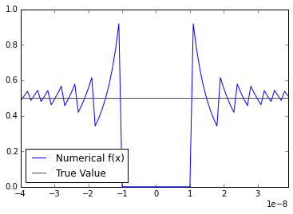

```python
def f(x) :
    return (1.-np.cos(x))/x**2

def g(x) :
    return (np.sin(.5*x)**2*2)/x**2

x = np.arange(-4e-8, 4e-8, 1e-9)
df = pd.DataFrame(np.array([f(x), g(x)]).T, index=x, columns=['Numerical f(x)', 'True Value']);
df.plot();
```

## How did it happen?

```python
x = 1.1e-8
print "cos(%.16e) = %.16f" % (x, cos(x))
print "1-cos(%.e) = %.16e" % (x, 1.-cos(x))
print "true value of 1-cos(%.e) = %.16e" % (x, 2*sin(.5*x)**2)
```

```
cos(1.0999999999999999e-08) = 0.9999999999999999
1-cos(1e-08) = 1.1102230246251565e-16
true value of 1-cos(1e-08) = 6.0499999999999997e-17
```

- Dramatic precision loss when subtracting numbers that are very similar
  - All the identical leading significants cancels
  - The result has much fewer number of significant digits
- Catestrophic cancellation could happen in practice
  - Deltas are often computed by bump and re-value
  - Very small bump sizes should be avoided

## A real example in Finance

the CIR process is widely used in quant finance, eg, in the short rate and Heston model:

$$ dr_t = \kappa(\mu - r) dt + \sigma \sqrt{r_t} dW_t $$

the variance of $r_t$ at $t > 0$:

$$\text{Var}[r_t | r_0] = \frac{r_0\sigma^2}{\kappa}(e^{-\kappa t} - e^{-2\kappa t}) + \frac{\mu\sigma^2}{2\kappa}(1-e^{-\kappa t})^2$$

how the catastrophic cancellation arises?

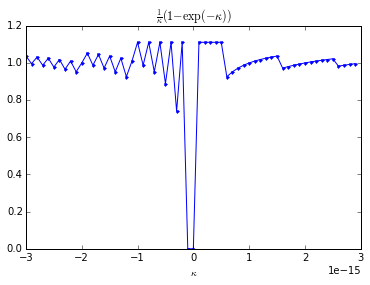

```python
k = arange(-3e-8, 3e-8, 1e-9)*1e-7
t = 1
v = (1-exp(-k*t))/k
plot(k, v, '.-')
title(r'$\frac{1}{\kappa}(1-\exp(-\kappa))$')
xlabel(r'$\kappa$');
```

## Condition number

Consider the relative error of a function with multiple arguments: $f = f(x_1, ..., x_n)$:

$$ \small df = \sum_i \frac{\partial f}{\partial x_i} dx_i \iff \frac{df}{f} = \sum_i \frac{x_i}{f}\frac{\partial f}{\partial x_i} \frac{dx_i}{x_i} $$

Assuming input argument's relative errors are $\epsilon_i$ (could be negative):

$$ \small \left| \frac{\Delta f}{f} \right| = \left| \sum_i \frac{x_i}{f}\frac{\partial f}{\partial x_i} \epsilon_i \right| \le \sum_i \left| \frac{x_i}{f}\frac{\partial f}{\partial x_i} \right| \left|\epsilon_i\right| \le \sum_i \left| \frac{x_i}{f}\frac{\partial f}{\partial x_i} \right| \epsilon_m \equiv k(f) \epsilon_m $$

where $\epsilon_m$ is the maximum relative error of all inputs.

- $k(f) = \sum_i \left| \frac{x_i}{f}\frac{\partial f}{\partial x_i} \right|$ is defined as the condition number of a function,
- it is the maximum growth factor of the relative error.
- the calculation loses about $\log_{10}(k(f))$ decimal digits of accuracy.

## Well-posed and ill-posed problems

Condition number is the systematic approach to detect potential numerical problems:

- $f(x_1, x_2) = x_1 - x_2$

  $k(f) = \frac{|x_1| + |x_2|}{|x_1 - x_2|}$, ill conditioned when $x_1 \approx x_2$, catestrophic cancellation
- $f(x_1, x_2) = x_1 x_2$

  $k(f) = 2$, the multiplication is well conditioned

The problem is ill-posed if its condition number is large.

- In practice, it is impossible to run condition number analysis over complicated calculations:
- We have to rely upon monitoring and testing

## Well-posed problem can be unstable

Consider the previous example of $f(x) = \frac{1}{x^2}(1-\cos(x))$:

$$ k(f) = \left| 2 + \frac{x \sin{\left (x \right )}}{\cos{\left (x \right )} - 1} \right| $$

The numerical algorithm can be unstable even if the problem itself is well-posed.

- A better algorithm near $x=0$ is $f(x) = \frac{2}{x^2}\sin^2(\frac{x}{2})$

But an ill-posed problem is always numerically unstable by definition.

- Direct numerical calculation is unstable around $x = 2\pi$
- Does this help? $f(x) \approx \frac{1}{2x^2}(x-2\pi)^2$

# Ill-posed numerical algorithm

Ill-posed problem are generally not suitable for numerical solutions.

The Mandelbrot set is a famous example:

- defined an iterative algorithm in complex number: $z_{i+1} = z_i^2 + c$
- the color of $z_0$ is tied to the number of iterations for $|z_i|$ to go above a threshold
- obviously unstable because of the iterative additions
- showing exquisite details of numerical instability

[figure not shown]

## Rules of engagement for floats

- Always allow errors when comparing numbers
- Use double precision floating point number by default
  - unless you know what you are doing (really?)
- Avoid adding and subtracting numbers of very different magnitudes
  - avoid using very small bump sizes when computing delta
- Take care of the limits, especially around 0
  - many (careless) numerical implementations broke down around 0
- Use well designed numerical libraries whenever possible
  - Even simple numerical algorithm can have spectacular pitfalls
- Test and monitor

## Portability

- Floating point computation is usually not reproducible across different platforms
- Same code will produce different results with different compiler and hardware
  - The difference can be significant in optimization and iterative methods
- Design your unit test to be cross platform by giving enough error allowance
- Test and monitoring are critical

## Assignments

Required Reading:

- Bindel and Goodman: Chapter 2

Recommended Reading:

- Review linear algebra (any elementary linear algebra book)
- Andersen and Piterbarg: Chapter 1

Homework

- Setup your python environment following the instructions at: http://yadongli.github.io/nyumath2048/
- Bindel and Goodman: Problem: 2.8
- Complete [Homework Set 1](http://yadongli.github.io/nyumath2048/)